# What is survival analysis?

Antoine Soetewey

4/18/2020

# Introduction

Although survival analysis is a branch of statistics, it is usually not covered in introductory statistics courses and it is rather unknown to the general public (and even to some statisticians).

In this article, I will try to explain what is survival analysis, in which context and how it is used. I will explain the main tools and methods used by biostatisticians to analyze survival data and how to estimate and interpret survival curves.

I will show in detail how to apply these techniques in R with concrete examples. In practice, survival analysis is almost always done via a statistical program and never done by hand. However, as for any statistical concept, I believe that doing it by hand allows to really understand the concept and what these programs actually do. For this reason, I will also show a brief example on how to perform a basic survival analysis by hand at the end of the article.

Note that this article is inspired from the lecture notes of Prof. Van Keilegom and my personal experience as teaching assistant for her course entitled “Analysis of Survival and Duration Data” (UCLouvain).

# What is survival analysis?

**Survival analysis** (also called time-to-event analysis or duration analysis) is a branch of statistics for **analyzing the expected duration of time until one or more events happen**, called survival times or duration times.

In survival analysis, we are interested in a certain event and want to **analyze the time until the event happens**.

While the event of interest is often death (in this case we study the time to death for patients having a specific disease) or recurrence (in this case we study the time to relapse of a certain disease), we may also analyze the time until:

- getting cured from a certain disease
- finding a new job after a period of unemployment
- being arrested again after being released from jail
- the failure of a mechanical system or a machine
- a bank or a company goes bankrupt
- a customer buys a new product or stops its current subscription
- a letter is delivered
- a taxi picks you up after having called the taxi company
- etc.

As you can see, the event of interest does not necessarily have to be death, but in all situations **we are interested in the time until a specific event occurs**.

# Why do we need special methods for survival analysis?

Survival data, also referred as time-to-event data, requires a special set of statistical methods for several reasons:

- **Duration times** are **always positive**: the time until an event of interest takes place cannot be less than 0. Many “standard” descriptive statistics and hypothesis tests are not appropriate for this kind of data.
- **Censoring** is almost always an issue:
  - The event is not yet observed at the end of the study. Suppose that we study the time until death of patients with breast cancer. Luckily, some patients will not die before the end of the study.
  - Another event takes place before the event of interest. For example, a cancer patient may die from a car accident.
  - Lost to follow up / drop out: the patient withdraws from the study or moves to another country and we cannot observe her survival time.
  - For these reasons, specific statistical methods are required to take into account the fact that we miss the precise survival of some patients. We know that they survived a certain amount of time (until the end of the study or until the time of withdrawal), but we do not know their exact survival time.
- **Different measures** are of interest depending on the research question, context, etc. We could be interested in, for example:
  - The **probability** that a cancer patient survives longer than 5 years?
  - The typical **waiting time** for a cab to arrive after having called the taxi company?
  - **How many**, out of 100 unemployed people, are expected to have a job again after 2 months?

The goal of survival analysis is thus to model and describe time-to-event data in an appropriate way, taking the particularities of this type of data into account.

# Common functions in survival analysis

We are not going to go to much into the details, but it is important to lay the foundation with the most common functions in survival analysis.

Let *T* be a non-negative continuous random variable, representing the time until the event of interest. We consider the following functions.

## Survival function

The most common one is the survival function:

$$S(t) = P(T > t) = 1 -
F(t)$$

It gives the probability that duration is longer than $t$. In the context of our examples mentioned above, it gives the probability that:

- a randomly selected patient will survive beyond time $t$,
- the cab takes more than $t$ minutes to arrive, or
- an unemployed person take more than $t$ months to find a new job.

The survival function is:

- a decreasing function,
- taking values in $[0, 1]$, and
- equal to 1 at $t = 0$ and 0 at $t = \infty$.

For example:

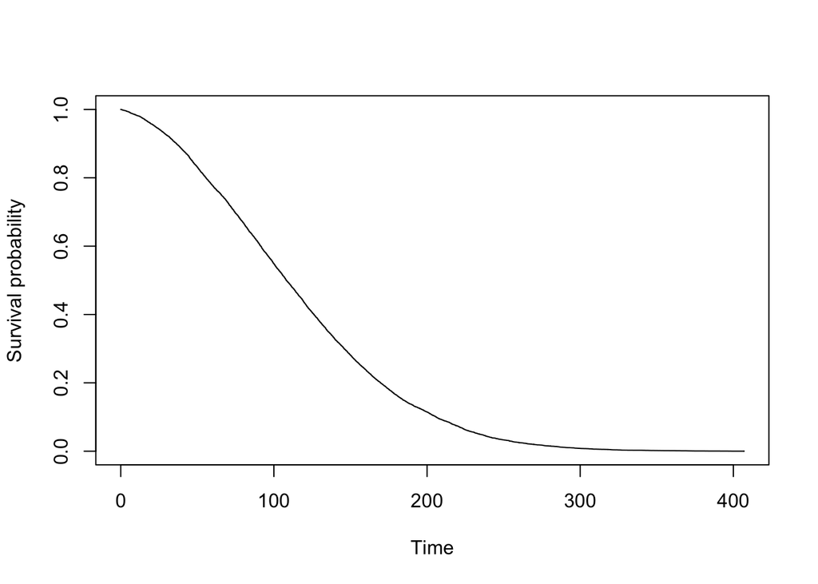

The curve shows the proportion of individuals (or experimental units) who, as time goes on, have not experienced an event. As time progresses, events occur, so the proportion who have not experienced the event decreases.

## Cumulative hazard function

The cumulative hazard function is defined as:

$$H(t) = -log S(t)$$

and has the following properties:

- increasing function,
- taking value in $[0, +\infty]$, and
- $S(t) = exp(-H(t))$

## The hazard function

The hazard function, or hazard rate, is defined as:

$$\begin{aligned}
h(t) &= \lim_{\Delta t \rightarrow 0} \frac{P(t \le T < t +
\Delta t | T \ge t)}{\Delta t}\\
&= \frac{d}{dt} H(t)
\end{aligned}$$

and has the following properties:

- positive function (not necessarily increasing or decreasing)
- the hazard function $h(t)$ can have many different shapes and is therefore a useful tool to summarize survival data

In the example of cancer patients, $h(t)$ measures the instantaneous risk of dying right after time $t$ given the individual is alive at time $t$.

To link the hazard rate with the survival function; the survival curve represents the hazard rates. A steeper slope indicates a higher hazard rate because events happen more frequently, reducing the proportion of individuals who have not experienced the event at a faster rate. On the contrary, a gradual slope indicates a lower hazard rate because events occur less frequently, reducing the proportion of individuals who have not experiences the event at a slower rate.

# Estimation

To estimate the survival function, we need to use an estimator which is able to deal with censoring. The most common one is the nonparametric **Kaplan-Meier estimator**.

## By hand

To understand how it works, let’s first estimate it by hand on the following dataset:

| subject | time | event |
| --- | --- | --- |
| 1 | 3 | 0 |
| 2 | 5 | 1 |
| 3 | 7 | 1 |
| 4 | 2 | 1 |
| 5 | 18 | 0 |
| 6 | 16 | 1 |
| 7 | 2 | 1 |
| 8 | 9 | 1 |
| 9 | 16 | 1 |
| 10 | 5 | 0 |

where:

- `subject` is the individual’s identifier
- `time` is the time to event (in years)[^1]
- `event` is the event status (0 = censored, 1 = event happened)

We first need to count the number of distinct event times. Ignoring censored observations, we have 5 distinct event times:

*2*, *5*, *7*, *9* and *16*

The easiest way to do the calculation by hand is by filling the following table (a table with 5 rows since there are 5 distinct event times):

| $j$ | $y_{(j)}$ | $d_{(j)}$ | $R_{(j)}$ | $1 - \frac{d_{(j)}}{R_{(j)}}$ |
| --- | --- | --- | --- | --- |
| 1 |  |  |  |  |
| 2 |  |  |  |  |
| 3 |  |  |  |  |
| 4 |  |  |  |  |
| 5 |  |  |  |  |

We fill columns one by one:

- $y_{(j)}$ = the ordered distinct event times:

*2*, *5*, *7*, *9* and *16*

So the table becomes:

| $j$ | $y_{(j)}$ | $d_{(j)}$ | $R_{(j)}$ | $1 - \frac{d_{(j)}}{R_{(j)}}$ |
| --- | --- | --- | --- | --- |
| 1 | 2 |  |  |  |
| 2 | 5 |  |  |  |
| 3 | 7 |  |  |  |
| 4 | 9 |  |  |  |
| 5 | 16 |  |  |  |

- $d_{(j)}$ = the number of observations for each distinct event time:

| 2 | 5 | 7 | 9 | 16 |
| --- | --- | --- | --- | --- |
| 2 | 1 | 1 | 1 | 2 |

The table becomes:

| $j$ | $y_{(j)}$ | $d_{(j)}$ | $R_{(j)}$ | $1 - \frac{d_{(j)}}{R_{(j)}}$ |
| --- | --- | --- | --- | --- |
| 1 | 2 | 2 |  |  |
| 2 | 5 | 1 |  |  |
| 3 | 7 | 1 |  |  |
| 4 | 9 | 1 |  |  |
| 5 | 16 | 2 |  |  |

- $R_{(j)}$ = the remaining number of individuals at risk. For this, the distribution of time (censored and not censored) is useful:

| 2 | 3 | 5 | 7 | 9 | 16 | 18 |
| --- | --- | --- | --- | --- | --- | --- |
| 2 | 1 | 2 | 1 | 1 | 2 | 1 |

We see that:

- At the beginning there are 10 subjects
- Just before time $t = 5$, there are 7 subjects left (10 subjects - 2 who had the event - 1 who is censored)
- Just before time $t = 7$, there are 5 subjects left (= 10 - 2 - 1 - 2)
- Just before time $t = 9$, there are 4 subjects left (= 10 - 2 - 1 - 2 - 1)
- Just before time $t = 16$, there are 3 subjects left (= 10 - 2 - 1 - 2 - 1 - 1)

The table becomes:

| $j$ | $y_{(j)}$ | $d_{(j)}$ | $R_{(j)}$ | $1 - \frac{d_{(j)}}{R_{(j)}}$ |
| --- | --- | --- | --- | --- |
| 1 | 2 | 2 | 10 |  |
| 2 | 5 | 1 | 7 |  |
| 3 | 7 | 1 | 5 |  |
| 4 | 9 | 1 | 4 |  |
| 5 | 16 | 2 | 3 |  |

- $1 - \frac{d_{(j)}}{R_{(j)}}$ is straigthforward, so the table becomes:

| $j$ | $y_{(j)}$ | $d_{(j)}$ | $R_{(j)}$ | $1 - \frac{d_{(j)}}{R_{(j)}}$ |
| --- | --- | --- | --- | --- |
| 1 | 2 | 2 | 10 | 0.8 |
| 2 | 5 | 1 | 7 | 0.857 |
| 3 | 7 | 1 | 5 | 0.8 |
| 4 | 9 | 1 | 4 | 0.75 |
| 5 | 16 | 2 | 3 | 0.333 |

The Kaplan-Meier estimator is:

$$\hat{S}_{KM}(t) = \prod_{j:y_{(j)} \le
t} \left(1 - \frac{d_{(j)}}{R_{(j)}} \right)$$

For each $j$, we thus take the cumulative product:

- $j_1 = 0.8$
- $j_2 = 0.8 \cdot 0.857 = 0.6856$
- $j_3 = 0.6856 \cdot 0.8 = 0.54848$
- $j_4 = 0.54848 \cdot 0.75 = 0.41136$
- $j_5 = 0.41136 \cdot 0.333 = 0.1369829$

So finally, we have the survival probabilities (rounded to 3 digits):

| $j$ | $1 - \frac{d_{(j)}}{R_{(j)}}$ | $\hat{S}_{KM}(t)$ |
| --- | --- | --- |
| 1 | 0.8 | 0.8 |
| 2 | 0.857 | 0.686 |
| 3 | 0.8 | 0.548 |
| 4 | 0.75 | 0.411 |
| 5 | 0.333 | 0.137 |

We can now represent graphically the Kaplan-Meier estimator:

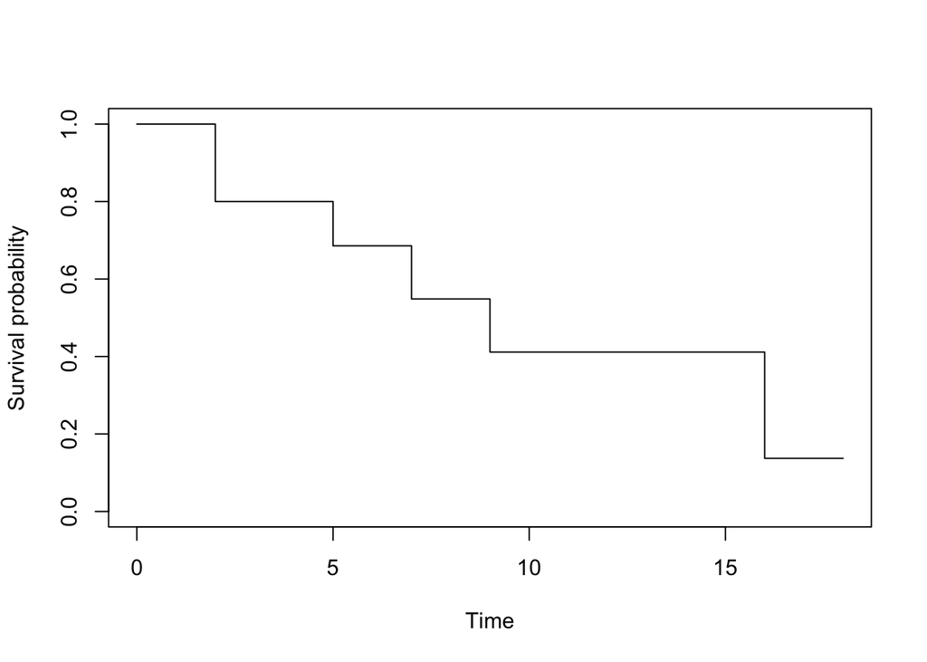

To draw this survival curve, remember that:

- the x-axis corresponds to the `time` variable in the initial dataset, and
- the y-axis corresponds to the survival probabilities found above.

## In R

We now compare our results with the results found in R.

We first create the dataset with the time and event variables:

```r
# create dataset
dat <- data.frame(
  time = c(3, 5, 7, 2, 18, 16, 2, 9, 16, 5),
  event = c(0, 1, 1, 1, 0, 1, 1, 1, 1, 0)
)
```

We then run the Kaplan-Meier estimator with the `survfit()` and `Surv()` functions:

```r
# KM
library(survival)
km <- survfit(Surv(time, event) ~ 1,
  data = dat
)
```

Notice that the `Surv()` function accepts two arguments:

1. the `time` variable, and
2. the `event` variable.

The `~ 1` in the `survfit()` function indicates that we estimate the Kaplan-Meier without any grouping. See more on this later in the post.

Finally, we display the results and draw the Kaplan-Meier plot:

```r
# results
summary(km)
```

```
## Call: survfit(formula = Surv(time, event) ~ 1, data = dat)
##
##  time n.risk n.event survival std.err lower 95% CI upper 95% CI
##     2     10       2    0.800   0.126       0.5868        1.000
##     5      7       1    0.686   0.151       0.4447        1.000
##     7      5       1    0.549   0.172       0.2963        1.000
##     9      4       1    0.411   0.176       0.1782        0.950
##    16      3       2    0.137   0.126       0.0225        0.834
```

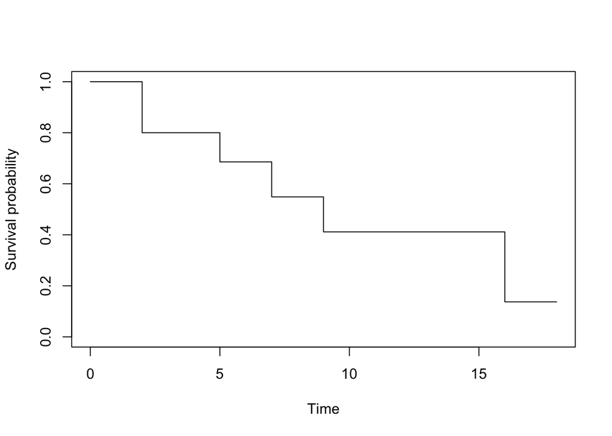

```r
# plot
plot(km,
  xlab = "Time",
  ylab = "Survival probability",
  conf.int = FALSE
)
```

The survival probabilities can be found in the `survival` column. Remark that results by hand and in R are similar (any difference with the results by hand is due to rounding).

Alternatively, we can use the `ggsurvplot()` function within the `{survminer}` package:

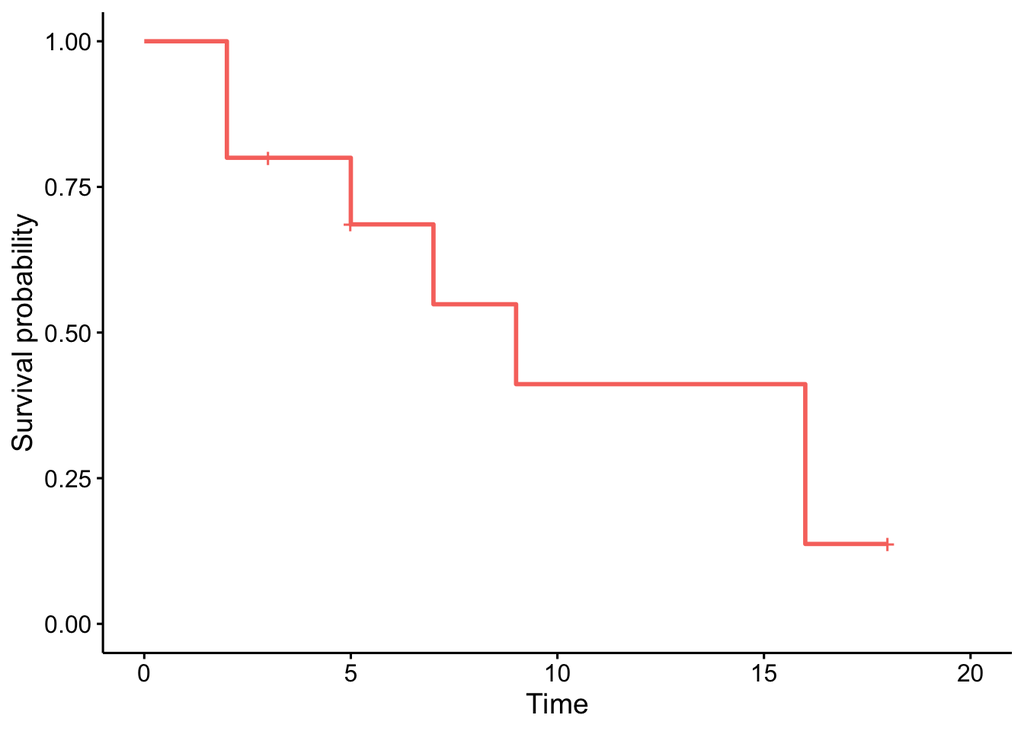

```r
library(survminer)

# plot
ggsurvplot(km,
  conf.int = FALSE,
  legend = "none"
)
```

*Note that the crosses on the survival curve denote the censored observations.*

The advantage with the `ggsurvplot()` function is that it is easy to draw the median directly on the plot:[^2]

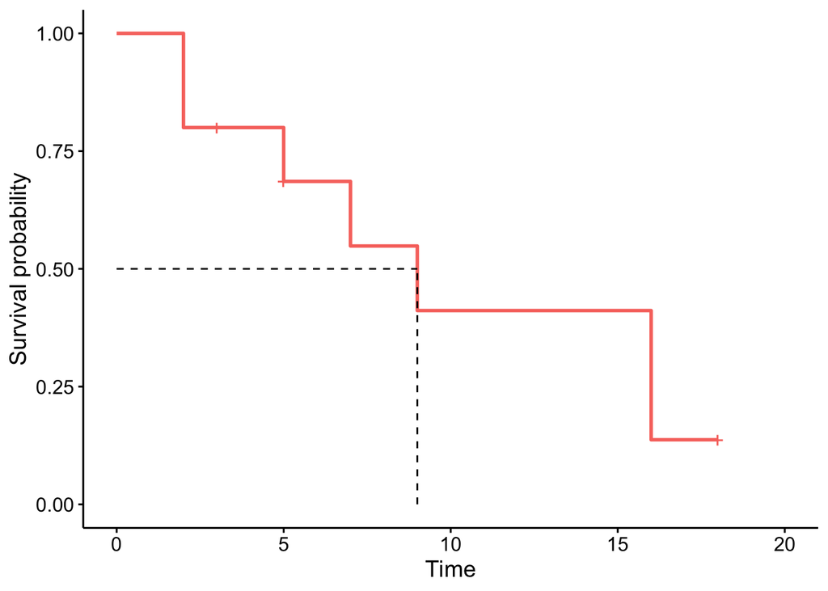

```r
ggsurvplot(km,
  data = dat,
  conf.int = FALSE,
  surv.median.line = "hv",
  legend = "none"
)
```

To find the median duration:

```r
summary(km)$table["median"]
```

```
## median
##      9
```

```r
# or more simply
km
```

```
## Call: survfit(formula = Surv(time, event) ~ 1, data = dat)
##
##       n events median 0.95LCL 0.95UCL
## [1,] 10      7      9       5      NA
```

For the sake of completeness, let’s do another example with a much larger dataset; the `tongue` dataset within the `{KMsurv}` package.[^4]

```r
# load data
library(KMsurv)
data(tongue)

# view data
head(tongue)
```

```
##   type time delta
## 1    1    1     1
## 2    1    3     1
## 3    1    3     1
## 4    1    4     1
## 5    1   10     1
## 6    1   13     1
```

- `type` is the tumor DNA profile (1 = aneuploid tumor, 2 = diploid tumor)
- `time` is the time to death or on-study time (in weeks)
- `delta` is the death indicator (0 = alive, 1 = dead)

For this example, we focus on the aneuploid type:

```r
anaploid <- subset(tongue, type == 1)
```

We can now plot the estimated survival function and estimate the median time to death (and find a 95% confidence interval for the median survival time):[^5]

```r
# results
fit <- survfit(Surv(time, delta) ~ 1,
  data = anaploid,
  conf.type = "log-log"
)
fit
```

```
## Call: survfit(formula = Surv(time, delta) ~ 1, data = anaploid, conf.type = "log-log")
##
##       n events median 0.95LCL 0.95UCL
## [1,] 52     31     93      65     157
```

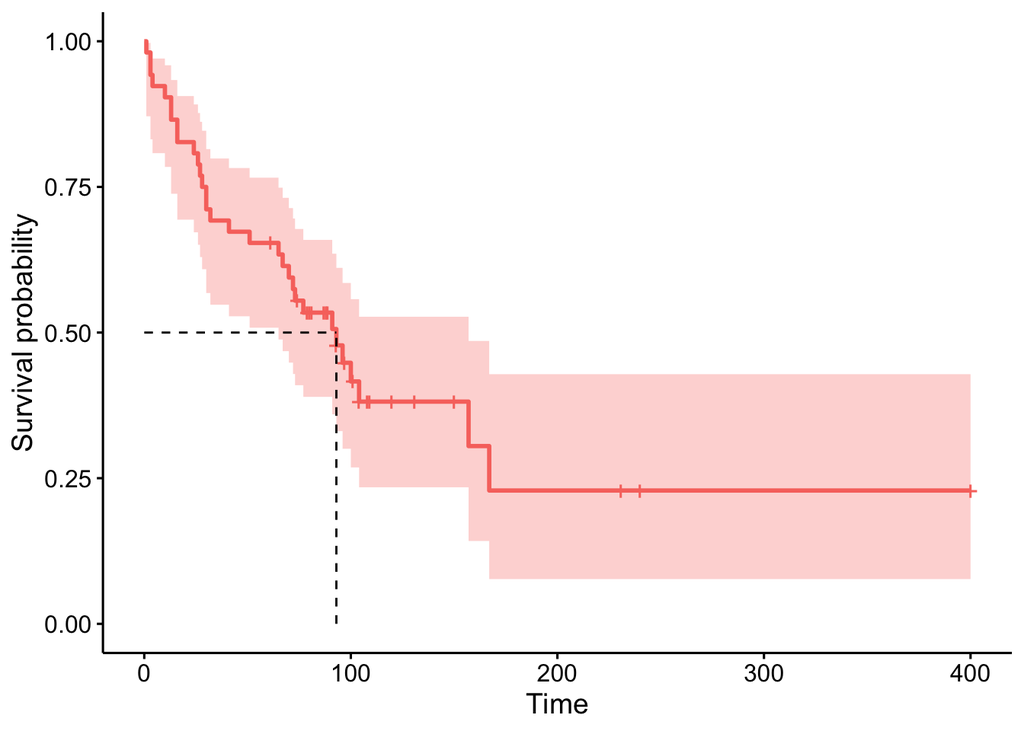

```r
# plot
ggsurvplot(fit,
  data = anaploid,
  surv.median.line = "hv",
  legend = "none"
)
```

The median survival time is estimated to be 93 weeks, with a 95% confidence interval [65; 157].

# Hypothesis testing

Hypothesis testing in the field of survival analysis mostly concerns:

- The hazard function of **one population**: in this case we test whether a censored sample comes from a population with a known hazard function $h_0(t)$. For example, we may be interested to compare survival in a sample of patients to the survival in the overall population (derived from the life tables).
- The comparison of the hazard function of **two or more populations**. For example:
  - 2 groups: we are interested in comparing survival for female and male colon cancer patients
  - 3 groups or more: we are interested in comparing survival for melanoma cancer patients according to their treatments (with treatments A, B and C)[^6]

## Log-rank test

In this article, we focus on comparing survival between two groups using the **log-rank test**.

The intuition behind the test is that if the two groups have different hazard rates, the two survival curves (so their slopes) will differ.

For this example, consider the following dataset:

| patient | group | time | event |
| --- | --- | --- | --- |
| 1 | 1 | 4.1 | 1 |
| 2 | 1 | 7.8 | 0 |
| 3 | 1 | 10 | 1 |
| 4 | 1 | 10 | 1 |
| 5 | 1 | 12.3 | 0 |
| 6 | 1 | 17.2 | 1 |
| 7 | 2 | 9.7 | 1 |
| 8 | 2 | 10 | 1 |
| 9 | 2 | 11.1 | 0 |
| 10 | 2 | 13.1 | 0 |
| 11 | 2 | 19.7 | 1 |
| 12 | 2 | 24.1 | 0 |

where:

- `patient` is the patient’s identifier
- `group` is the group (group 1 or 2)
- `time` is the time to death (in years)[^7]
- `event` is the event status (0 = censored, 1 = death)

Suppose we are interested in comparing group 1 and 2 in terms of survival, that is:

- $H_0 : h_1(t) = h_2(t)$ for all $t \le Y_{(r)}$
- $H_1 : h_1(t) \ne h_2(t)$ for some $t \le Y_{(r)}$

To perform the log-rank test, the following test statistic will be useful:

$$\begin{eqnarray}
U &=& \sum_{j=1}^r w(y_{(j)})\left(O_j - E_j\right) \\
&=& \sum_{j=1}^r w(y_{(j)})\left( d_{(j)1} -
\frac{d_{(j)}R_{(j)1}}{R_{(j)}}\right)
\end{eqnarray}$$

with $U^{obs} = \frac{U}{\sqrt{Var(U)}} \sim N(0,1)$[^8] and

$$\begin{eqnarray}
Var(U) &=& \sum_{j=1}^r w^2(y_{(j)}) \frac{N_{(j)}}{
D_{(j)} }\\
&=& \sum_{j=1}^r w^2(y_{(j)}) \frac{ d_{(j)}
\frac{R_{(j)1}}{R_{(j)} } \left( 1 - \frac{R_{(j)1}}{R_{(j)} } \right)
\left( R_{(j)} - d_{(j)}\right) }{ R_{(j)} - 1 }
\end{eqnarray}$$

### By hand

As for the Kaplan-Meier estimator by hand, it is best to also fill in a table for the log-rank test by hand.

Let’s present the final table and comment below on how to fill it, column by column:

| $j$ | $y_{(j)}$ | $d_{(j)1}$ | $R_{(j)1}$ | $d_{(j)2}$ | $R_{(j)2}$ | $d_{(j)}$ | $R_{(j)}$ | $E_{j}$ | $O_{j}$ | $O_{j} - E_{j}$ | $N_{(j)}$ | $D_{(j)}$ | $N_{(j)}/D_{(j)}$ |
| --- | --- | --- | --- | --- | --- | --- | --- | --- | --- | --- | --- | --- | --- |
| 1 | 4.1 | 1 | 6 | 0 | 6 | 1 | 12 | 0.5 | 1 | 0.5 | 2.75 | 11 | 0.25 |
| 2 | 9.7 | 0 | 4 | 1 | 6 | 1 | 10 | 0.4 | 0 | -0.4 | 2.16 | 9 | 0.24 |
| 3 | 10 | 2 | 4 | 1 | 5 | 3 | 9 | 1.333 | 2 | 0.667 | 4.44 | 8 | 0.555 |
| 4 | 17.2 | 1 | 1 | 0 | 2 | 1 | 3 | 0.333 | 1 | 0.667 | 0.44 | 2 | 0.22 |
| 5 | 19.7 | 0 | 0 | 1 | 2 | 1 | 2 | 0 | 0 | 0 | 0.00 | 1 | 0.00 |
| $Total$ |  | 4 |  | 3 |  | 7 |  | 2.566 |  | 1.433 |  |  | 1.265 |

**Column $j$** is the number of distinct event times. We see that there are 5 (ignoring censored observations), so we write 1 to 5 in the table.

**Column $y_{(j)}$** is the ordered distinct event times:

*4.1*, *9.7*, *10*, *17.2* and *19.7*

**Column $d_{(j)1}$** is the number of observations for each distinct event time, for group 1:

| 4.1 | 10 | 17.2 |
| --- | --- | --- |
| 1 | 2 | 1 |

When there is no event, we simply write 0 in the table.

**Column $R_{(j)1}$** is the remaining number of patients at risk, for group 1. For this, the distribution of time (censored and not censored, for group 1) is useful:

| 4.1 | 7.8 | 10 | 12.3 | 17.2 |
| --- | --- | --- | --- | --- |
| 1 | 1 | 2 | 1 | 1 |

We see that:

- At the beginning, there are 6 patients
- Before time 9.7, there are 4 patients left (6 - 1 who had the event at time 4.1 - 1 who was censored at time 7.8)
- Before time 10, there are 4 patients left (6 - 2)
- Before time 17.2, there are 1 patient left (6 - 5)
- Before time 19.7, there are 0 patient left (6 - 6)

**Columns $d_{(j)2}$ and $R_{(j)2}$** follow the same principle, but for group 2 this time. So we have, respectively for $d_{(j)2}$ and $R_{(j)2}$:

| 9.7 | 10 | 19.7 |
| --- | --- | --- |
| 1 | 1 | 1 |

| 9.7 | 10 | 11.1 | 13.1 | 19.7 | 24.1 |
| --- | --- | --- | --- | --- | --- |
| 1 | 1 | 1 | 1 | 1 | 1 |

**Columns $d_{(j)}$ and $R_{(j)}$** also follow the same principle, but this time considering both groups. So we have, respectively for $d_{(j)}$ and $R_{(j)}$:

| 4.1 | 9.7 | 10 | 17.2 | 19.7 |
| --- | --- | --- | --- | --- |
| 1 | 1 | 3 | 1 | 1 |

| 4.1 | 7.8 | 9.7 | 10 | 11.1 | 12.3 | 13.1 | 17.2 | 19.7 | 24.1 |
| --- | --- | --- | --- | --- | --- | --- | --- | --- | --- |
| 1 | 1 | 1 | 3 | 1 | 1 | 1 | 1 | 1 | 1 |

**Column $E_{j}$** is the expected number of events in the first group assuming that $h1 \equiv h2$. It is obtained as follows

$$E_{j} =
\frac{d_{(j)}R_{(j)1}}{R_{(j)}}$$

**Column $O_{j}$** is the observed number of events in the first group, so it is equal to the $d_{(j)1}$ column.

**Column $O_{j} - E_{j}$** is straightforward.

**Column $N_{(j)}$** is defined as follows

$$N_{(j)} = d_{(j)}
\frac{R_{(j)1}}{R_{(j)} } \left( 1 - \frac{R_{(j)1}}{R_{(j)} } \right)
\left( R_{(j)} - d_{(j)}\right)$$

**Column $D_{(j)}$** is $R_{(j)} - 1$.

**Column $N_{(j)}/D_{(j)}$** is straightforward.

Since $w(y_{(j)}) = w^2(y_{(j)}) = 1$ for a log-rank test, we have[^9]

$$U^{obs} = \frac{U}{\sqrt{Var(U)}} =
\frac{1.434}{\sqrt{1.265}} = 1.275.$$

We reject $H_0$ if $|U^{obs}|>z_{1-\alpha/2}$, so at the 5% significance level we reject $H_0$ if $|U^{obs}|>z_{0.975}=1.96$.

We have $|U^{obs}| = 1.275 < z_{0.975}=1.96$. Hence, at the 5% significance level we do not reject $H_0$. This means that, based on the data, we are not able to conclude that survival is different between the two groups (which is equilavent than saying that we do not reject the hypothesis that survival is equal between the two groups).

If you are interested in computing the $p$-value:

$p$-value $= 2\times P(Z>1.275) = 2 \times 0.101 = 0.202 > 0.05$.

### In R

We now compare our results in R with the `survdiff()` function:

```r
dat <- data.frame(
  group = c(rep(1, 6), rep(2, 6)),
  time = c(4.1, 7.8, 10, 10, 12.3, 17.2, 9.7, 10, 11.1, 13.1, 19.7, 24.1),
  event = c(1, 0, 1, 1, 0, 1, 1, 1, 0, 0, 1, 0)
)

dat
```

```
##    group time event
## 1      1  4.1     1
## 2      1  7.8     0
## 3      1 10.0     1
## 4      1 10.0     1
## 5      1 12.3     0
## 6      1 17.2     1
## 7      2  9.7     1
## 8      2 10.0     1
## 9      2 11.1     0
## 10     2 13.1     0
## 11     2 19.7     1
## 12     2 24.1     0
```

```r
survdiff(Surv(time, event) ~ group,
  data = dat
)
```

```
## Call:
## survdiff(formula = Surv(time, event) ~ group, data = dat)
##
##         N Observed Expected (O-E)^2/E (O-E)^2/V
## group=1 6        4     2.57     0.800      1.62
## group=2 6        3     4.43     0.463      1.62
##
##  Chisq= 1.6  on 1 degrees of freedom, p= 0.2
```

Alternatively, we can use the `ggsurvplot()` function to draw the survival curves and perform the log-rank test at the same time:

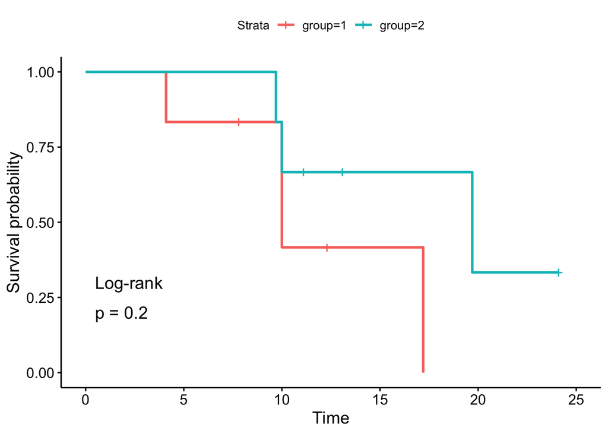

```r
fit <- survfit(Surv(time, event) ~ group, data = dat)
ggsurvplot(fit,
  data = dat,
  pval = TRUE,
  pval.method = TRUE
)
```

As we can see, the $p$-values and the conclusions are the same (any difference with the results by hand is due to rounding).

As for the Kaplan-Meier estimation, we do another example on a larger dataset. Consider the data on the times until staphylococcus infection of burn patients, also available in the `{KMsurv}`:[^10]

```r
# load data
data(burn)

# view data
head(burn)
```

```
##   Obs Z1 Z2 Z3 Z4 Z5 Z6 Z7 Z8 Z9 Z10 Z11 T1 D1 T2 D2 T3 D3
## 1   1  0  0  0 15  0  0  1  1  0   0   2 12  0 12  0 12  0
## 2   2  0  0  1 20  0  0  1  0  0   0   4  9  0  9  0  9  0
## 3   3  0  0  1 15  0  0  0  1  1   0   2 13  0 13  0  7  1
## 4   4  0  0  0 20  1  0  1  0  0   0   2 11  1 29  0 29  0
## 5   5  0  0  1 70  1  1  1  1  0   0   2 28  1 31  0  4  1
## 6   6  0  0  1 20  1  0  1  0  0   0   4 11  0 11  0  8  1
```

Using the log-rank test, we want to test the hypothesis of no difference in the time to staphylococcus infection (`T3` variable) between patients whose burns were cared for with a routine bathing care method (`Z1 = 0`) versus those whose body cleansing was initially performed using 4% chlorhexidine gluconate (`Z1 = 1`). The event indicator is in variable `D3`.

For this test, we use a two-sided alternative and a 5% significance level.

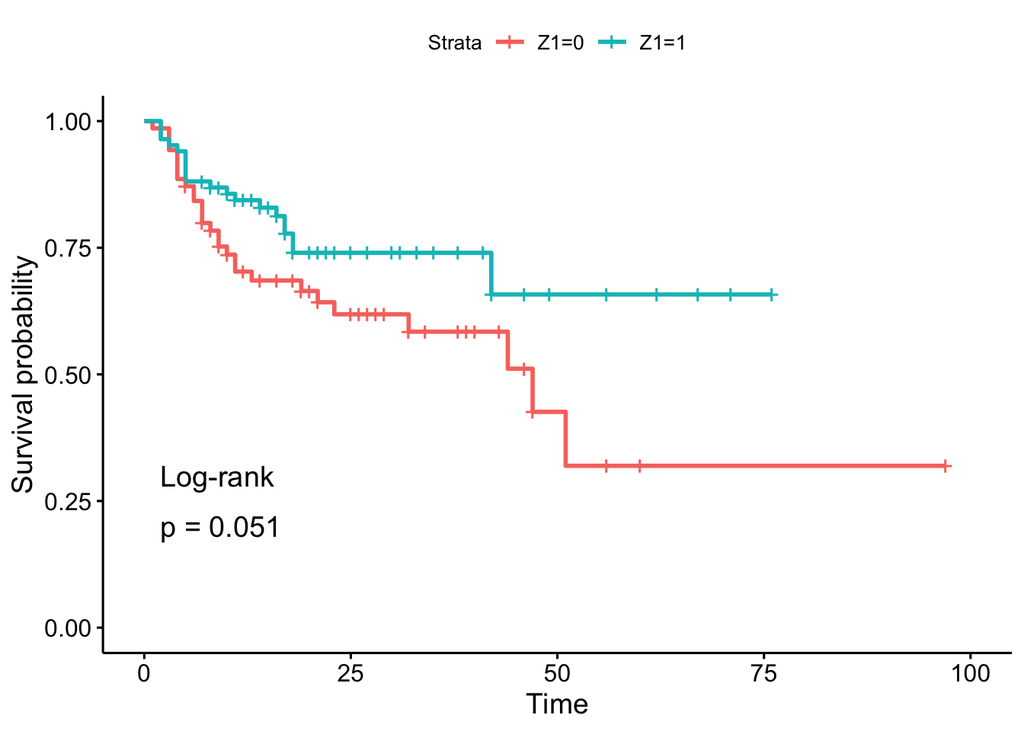

```r
# fit
fit <- survfit(Surv(T3, D3) ~ Z1, data = burn)

# plot with log-rank test
ggsurvplot(fit,
  data = burn,
  pval = TRUE,
  pval.method = TRUE
)
```

*In the sample*, it seems that the time to infection for patients with routine bathing (`Z1 = 0`) is smaller than for patients with body cleansing (`Z1 = 1`). This is the case because the percentage of patients who have not experienced the infection decreases more quickly, so the hazard rate is greater.

However, this conclusion cannot be generalized to the *population* without performing a sound statistical test. And based on the result of the log-rank test, we do not reject the hypothesis that time to infection is the same between the two groups of patients ($p$-value = 0.051).